# TidyModels: modeltime + GlobalModels

UPDATE: 2022-12-26 18:28:37

# はじめに

`tidymodels`パッケージの使い方をいくつかのノートに分けてまとめている。`tidymodels`パッケージは、統計モデルや機械学習モデルを構築するために必要なパッケージをコレクションしているパッケージで、非常に色んなパッケージがある。ここでは、今回は`modeltime`パッケージで複数の時系列を予測する方法についてまとめていく。モデルの数理的な側面や機械学習の用語などは、このノートでは扱わない。

下記の公式ドキュメントや`tidymodels`パッケージに関する書籍を参考にしている。

- [Tidymodels](https://www.tidymodels.org/)
- [Tidy Modeling with R](https://www.tmwr.org/software-modeling.html)

## `modeltime`パッケージの目的

`modeltime`パッケージは、時系列モデルの構築を効率よく行うためのパッケージで、`tidymodels`パッケージと組み合わせて時系列モデルを作成する際に使用される。時系列予測のための体系的なワークフローを提供し、時系列ブーストモデルなど新しいアルゴリズムもカバーしている点が特徴的。

ここでは、複数の時系列データがある場合に効率よく予測モデルを構築する方法をまとめる。

- [Forecasting with Global Models](https://business-science.github.io/modeltime/articles/modeling-panel-data.html)
- [Nested Forecasting](https://business-science.github.io/modeltime/articles/nested-forecasting.html)
- [Forecasting Many Time Series (Using NO For-Loops)](https://www.business-science.io/code-tools/2021/07/19/modeltime-panel-data.html)
- [Global Models with Modeltime](https://albertoalmuinha.com/posts/2021-08-02-global-models/global-models/)

上記のドキュメントやサイトをなぞりながら、不明点を追記しながらまとめていく。

## グローバルモデリング

多数の時系列を予測を行う場合、方法としては2つある。1つ目は、各時系列に対してモデルを作成し、繰り返して予測を行なう方法。2つ目は、時系列分野での呼び方なのか、`modeltime`パッケージ特有の言葉なのかわからないが、GlobalModelを用いる方法。これは、すべての時系列の予測を生成する1つのモデルのみが作成され、このモデルを用いて、各時系列の予測を行なう。双方、メリット・デメリットは存在するものの、スケーラビリティを考えるのであれば、後者の方法が望ましい。

例えば、精度に関しては1つ目の方法の方が優れている可能性があるが、数百の店舗がある場合に、数百のモデルを作成する必要があり、時間がかかる、多くのメモリが必要になる可能性がある。

グローバルモデリングの文脈ではパネルデータが重要になる。パネルデータは各種様々な指標に関して、複数の系列が同じ間隔で記録されているデータのフォーマット。パネルデータの文脈で先程のことを考えると、パネルが100個あれば、100個分のモデル作成を行い、100個分の予測を繰り返すことになる。グローバルモデリングでは、100個分のパネルに対して、1つのモデルを作成し、100個分の予測を行なう。

ただ、グローバルモデルは特徴量エンジニアリングがうまくできないと、精度が低くなってしまう。そのため、特徴量エンジニアリングが非常に重要になる。

## モデルの作成

まずは必要なパッケージを読み込んでおく。

```r
library(tidymodels)
library(modeltime)
library(tidyverse)
library(timetk)
library(DT)
```

使用するデータは、`modeltime`パッケージの`walmart_sales_weekly`データ。`Store`と`Dept`を識別する`id`、週開始日`date`、週売上`value`を利用する。

```r
data_table <- walmart_sales_weekly %>%
    select(id, Date, Weekly_Sales) %>%
    set_names(c("id", "date", "value"))

data_table
```

```
## # A tibble: 1,001 × 3
##    id    date        value
##    <fct> <date>      <dbl>
##  1 1_1   2010-02-05 24924.
##  2 1_1   2010-02-12 46039.
##  3 1_1   2010-02-19 41596.
##  4 1_1   2010-02-26 19404.
##  5 1_1   2010-03-05 21828.
##  6 1_1   2010-03-12 21043.
##  7 1_1   2010-03-19 22137.
##  8 1_1   2010-03-26 26229.
##  9 1_1   2010-04-02 57258.
## 10 1_1   2010-04-09 42961.
## # … with 991 more rows
```

`id`のユニーク数は7個なので、ウォルマートの7店舗分の2010-02-05から2012-10-26までの週売上が143レコードづつ記録されている。

```r
data_table %>%
  group_by(id) %>%
  summarise(
    n.obs = n(),
    start_date = min(date),
    end_date = max(date),
    min_value = min(value),
    mean_value = mean(value),
    max_value = max(value)
  )
```

```
## # A tibble: 7 × 7
##   id    n.obs start_date end_date   min_value mean_value max_value
##   <fct> <int> <date>     <date>         <dbl>      <dbl>     <dbl>
## 1 1_1     143 2010-02-05 2012-10-26    14537.     22513.    57592.
## 2 1_3     143 2010-02-05 2012-10-26     6166.     13150.    51159.
## 3 1_8     143 2010-02-05 2012-10-26    31061.     35718.    42664.
## 4 1_13    143 2010-02-05 2012-10-26    32782.     38693.    44863.
## 5 1_38    143 2010-02-05 2012-10-26    55974.     79978.   127812.
## 6 1_93    143 2010-02-05 2012-10-26    55082.     71699.    97980.
## 7 1_95    143 2010-02-05 2012-10-26    93359.    120772.   148798.
```

`plot_time_series`関数を利用すると、一気に売上推移を可視化できる。これをみると、売上規模として、4つくらいに分類できそうで、どの時系列も特有の特徴を持っていることがわかる。つまり、各時系列に特有の特徴量がなければ、予測が難しそうなことがわかる。

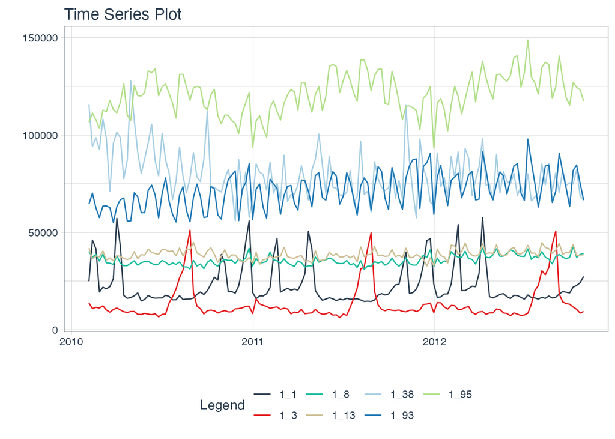

```r
data_table %>%
  #group_by(id) %>%
  plot_time_series(
    date,
    value,
    .color_var = id,
    .smooth = FALSE,
    .interactive = FALSE,
    .facet_ncol = 3
  )
```

時系列を分けて可視化したいときはグループ化すればよい。

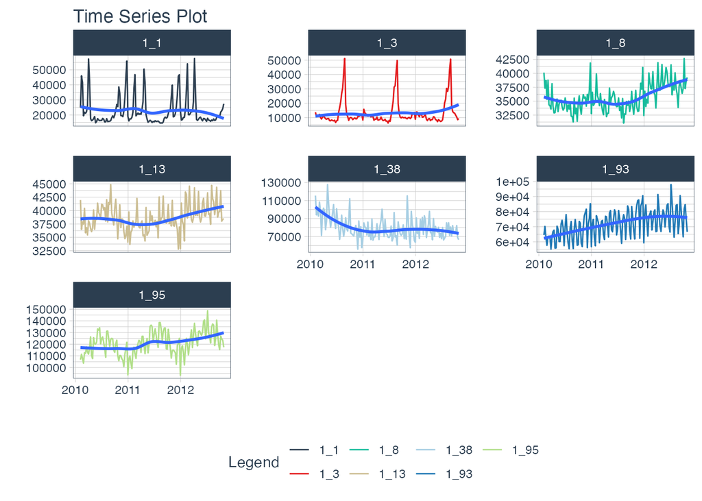

```r
data_table %>%
  group_by(id) %>%
  plot_time_series(
    date,
    value,
    .color_var = id,
    .interactive = FALSE,
    .facet_ncol = 3
  )
```

ドキュメントに従って、`time_series_split`関数を利用して、データを学習セットとテストセット(3 か月分)に分割する。重複するタイムスタンプが検出された。スライディングウィンドウを使って、重なり合った時系列を一緒に処理する、というインフォメーションが表示される。

```r
splits <- data_table %>%
  time_series_split(
    assess     = "3 months",
    cumulative = TRUE
  )
df_train <- splits %>% training()
df_test <- splits %>% testing()

bind_rows(
  df_train %>% summarise(start_date = min(date), end_date = max(date), records = n()),
  df_test %>% summarise(start_date = min(date), end_date = max(date), records = n())
)
```

```
## # A tibble: 2 × 3
##   start_date end_date   records
##   <date>     <date>       <int>
## 1 2010-02-05 2012-08-03     917
## 2 2012-08-10 2012-10-26      84
```

グラフ化しておく。

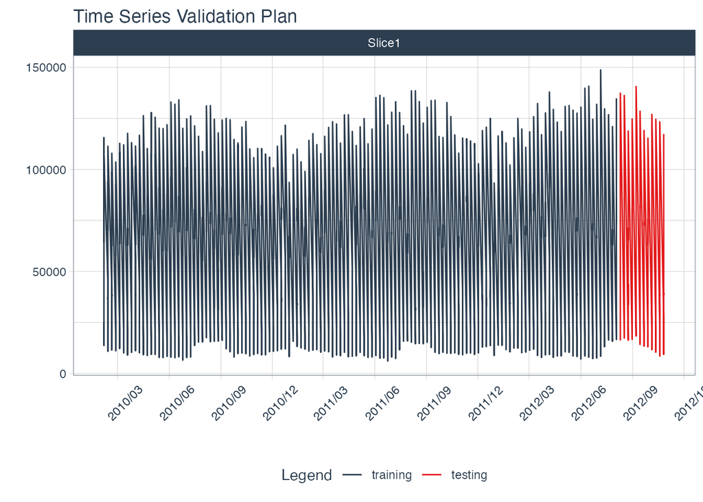

```r
splits %>%
  tk_time_series_cv_plan() %>%
  plot_time_series_cv_plan(date, value, .interactive = FALSE,
                           .title = "Time Series Validation Plan") +
  scale_x_date(limits = c(as.Date("2010-02-01"), as.Date("2012-11-01")),
               labels = date_format("%Y/%m"),
               breaks = date_breaks("3 month")) +
  theme(axis.text.x = element_text(angle = 45, vjust = 0.2, hjust=0.2))
```

モデリングのためのレシピを作成する。このレシピが行っている処理を理解するために、必要な列だけ残して可視化する。大枠として、2010-02-05のレコードを対象にすると、2010-02-05が`id`の分だけ積み上げられており、`id_X*_*`というカラムでレコードが管理されていることがわかる。

```r
recipe(value ~ ., df_train) %>%
  step_mutate_at(id, fn = droplevels) %>%
  step_timeseries_signature(date) %>%
  step_zv(all_predictors()) %>%
  step_dummy(all_nominal_predictors(), one_hot = TRUE) %>%
  prep() %>%
  bake(df_train) %>%
  select(date, value, date_week, contains("id")) %>%
  DT::datatable()
```

|  | date | value | date_week | id_X1_1 | id_X1_3 | id_X1_8 | id_X1_13 | id_X1_38 | id_X1_93 | id_X1_95 |
| --- | --- | --- | --- | --- | --- | --- | --- | --- | --- | --- |
| 1 | 2010-02-05 | 24924.5 | 6 | 1 | 0 | 0 | 0 | 0 | 0 | 0 |
| 2 | 2010-02-05 | 13740.12 | 6 | 0 | 1 | 0 | 0 | 0 | 0 | 0 |
| 3 | 2010-02-05 | 40129.01 | 6 | 0 | 0 | 1 | 0 | 0 | 0 | 0 |
| 4 | 2010-02-05 | 41969.29 | 6 | 0 | 0 | 0 | 1 | 0 | 0 | 0 |
| 5 | 2010-02-05 | 115564.35 | 6 | 0 | 0 | 0 | 0 | 1 | 0 | 0 |
| 6 | 2010-02-05 | 64494.87 | 6 | 0 | 0 | 0 | 0 | 0 | 1 | 0 |
| 7 | 2010-02-05 | 106690.06 | 6 | 0 | 0 | 0 | 0 | 0 | 0 | 1 |
| 8 | 2010-02-12 | 46039.49 | 7 | 1 | 0 | 0 | 0 | 0 | 0 | 0 |
| 9 | 2010-02-12 | 10887.84 | 7 | 0 | 1 | 0 | 0 | 0 | 0 | 0 |
| 10 | 2010-02-12 | 37334.83 | 7 | 0 | 0 | 1 | 0 | 0 | 0 | 0 |

[output cut: 907 more lines]

このような形で、各`id`ごとに`917/7=131`レコードを積み上げているデータを利用する。

```r
recipe(value ~ ., df_train) %>%
  step_mutate_at(id, fn = droplevels) %>%
  step_timeseries_signature(date) %>%
  step_zv(all_predictors()) %>%
  step_dummy(all_nominal_predictors(), one_hot = TRUE) %>%
  prep() %>%
  bake(df_train) %>%
  select(date, value, date_week, contains("id")) %>%
  filter(id_X1_1 == 1) %>%
  datatable()
```

|  | date | value | date_week | id_X1_1 | id_X1_3 | id_X1_8 | id_X1_13 | id_X1_38 | id_X1_93 | id_X1_95 |
| --- | --- | --- | --- | --- | --- | --- | --- | --- | --- | --- |
| 1 | 2010-02-05 | 24924.5 | 6 | 1 | 0 | 0 | 0 | 0 | 0 | 0 |
| 2 | 2010-02-12 | 46039.49 | 7 | 1 | 0 | 0 | 0 | 0 | 0 | 0 |
| 3 | 2010-02-19 | 41595.55 | 8 | 1 | 0 | 0 | 0 | 0 | 0 | 0 |
| 4 | 2010-02-26 | 19403.54 | 9 | 1 | 0 | 0 | 0 | 0 | 0 | 0 |
| 5 | 2010-03-05 | 21827.9 | 10 | 1 | 0 | 0 | 0 | 0 | 0 | 0 |
| 6 | 2010-03-12 | 21043.39 | 11 | 1 | 0 | 0 | 0 | 0 | 0 | 0 |
| 7 | 2010-03-19 | 22136.64 | 12 | 1 | 0 | 0 | 0 | 0 | 0 | 0 |
| 8 | 2010-03-26 | 26229.21 | 13 | 1 | 0 | 0 | 0 | 0 | 0 | 0 |
| 9 | 2010-04-02 | 57258.43 | 14 | 1 | 0 | 0 | 0 | 0 | 0 | 0 |
| 10 | 2010-04-09 | 42960.91 | 15 | 1 | 0 | 0 | 0 | 0 | 0 | 0 |

[output cut: 121 more lines]

この後で利用するモデルでは、`date`カラムは不要なので、先程のレシピから`step_rm(date)`で削除しておく。

```r
recipe <- recipe(value ~ ., df_train) %>%
    step_mutate_at(id, fn = droplevels) %>%
    step_timeseries_signature(date) %>%
    step_rm(date) %>%
    step_zv(all_predictors()) %>%
    step_dummy(all_nominal_predictors(), one_hot = TRUE)

summary(prep(recipe)) %>% print(n = 50)
```

```
## # A tibble: 38 × 4
##    variable          type      role      source
##    <chr>             <list>    <chr>     <chr>
##  1 value             <chr [2]> outcome   original
##  2 date_index.num    <chr [2]> predictor derived
##  3 date_year         <chr [2]> predictor derived
##  4 date_year.iso     <chr [2]> predictor derived
##  5 date_half         <chr [2]> predictor derived
##  6 date_quarter      <chr [2]> predictor derived
##  7 date_month        <chr [2]> predictor derived
##  8 date_month.xts    <chr [2]> predictor derived
##  9 date_day          <chr [2]> predictor derived
## 10 date_mday         <chr [2]> predictor derived
## 11 date_qday         <chr [2]> predictor derived
## 12 date_yday         <chr [2]> predictor derived
```

[output cut: 26 more lines]

レシピが完成したので、モデルとワークフローを作成し、学習データでフィッティングする。パラメタチューニングなどはここでは一旦スルーする。

```r
model <- boost_tree("regression") %>%
  set_engine("xgboost")

workflow <- workflow() %>%
    add_model(model) %>%
    add_recipe(recipe)

workflow_fit <- workflow %>%
  fit(df_train)

workflow_fit
```

```
## ══ Workflow [trained] ══════════════════════════════════════════════════════════
## Preprocessor: Recipe
## Model: boost_tree()
##
## ── Preprocessor ────────────────────────────────────────────────────────────────
## 5 Recipe Steps
##
## • step_mutate_at()
## • step_timeseries_signature()
## • step_rm()
## • step_zv()
## • step_dummy()
##
## ── Model ───────────────────────────────────────────────────────────────────────
## ##### xgb.Booster
## raw: 46.5 Kb
## call:
##   xgboost::xgb.train(params = list(eta = 0.3, max_depth = 6, gamma = 0,
##     colsample_bytree = 1, colsample_bynode = 1, min_child_weight = 1,
##     subsample = 1), data = x$data, nrounds = 15, watchlist = x$watchlist,
##     verbose = 0, nthread = 1, objective = "reg:squarederror")
## params (as set within xgb.train):
##   eta = "0.3", max_depth = "6", gamma = "0", colsample_bytree = "1", colsample_bynode = "1", min_child_weight = "1", subsample = "1", nthread = "1", objective = "reg:squarederror", validate_parameters = "TRUE"
## xgb.attributes:
##   niter
## callbacks:
##   cb.evaluation.log()
## # of features: 37
## niter: 15
## nfeatures : 37
## evaluation_log:
##     iter training_rmse
##        1     46315.130
##        2     33003.670
## ---
##       14      3554.521
##       15      3423.419
```

ここから`modeltime`のワークフローを利用する。フィッティングが完了しているモデルをモデルテーブルに登録する。

```r
model_table <- modeltime_table(
    workflow_fit
)
model_table
```

```
## # Modeltime Table
## # A tibble: 1 × 3
##   .model_id .model     .model_desc
##       <int> <list>     <chr>
## 1         1 <workflow> XGBOOST
```

```r
calibration_table <- model_table %>%
    modeltime_calibrate(
      new_data = df_test,
      id = "id"
    )
calibration_table
```

```
## # Modeltime Table
## # A tibble: 1 × 5
##   .model_id .model     .model_desc .type .calibration_data
##       <int> <list>     <chr>       <chr> <list>
## 1         1 <workflow> XGBOOST     Test  <tibble [84 × 5]>
```

`.calibration_data`カラムの中身を見ると、各`id`の日付ごとに予測値が算出されていることがわかる。

```r
calibration_table %>%
  pluck(".calibration_data", 1)
```

```
## # A tibble: 84 × 5
##    date       .actual .prediction .residuals id
##    <date>       <dbl>       <dbl>      <dbl> <fct>
##  1 2012-08-10  16120.      19091.     -2971. 1_1
##  2 2012-08-10  28257.      31012.     -2755. 1_3
##  3 2012-08-10  37270.      35225.      2045. 1_8
##  4 2012-08-10  42241.      39167.      3074. 1_13
##  5 2012-08-10  74483.      69858.      4625. 1_38
##  6 2012-08-10  84119.      78213.      5907. 1_93
##  7 2012-08-10 137408.     130517.      6891. 1_95
##  8 2012-08-17  17331.      19091.     -1760. 1_1
##  9 2012-08-17  31906.      40312.     -8406. 1_3
## 10 2012-08-17  36294.      35225.      1069. 1_8
## # … with 74 more rows
```

`id`を`1_1`のレコードに絞ってみるとわかりやすい。

```r
calibration_table %>%
  pluck(".calibration_data", 1) %>%
  filter(id == "1_1")
```

```
## # A tibble: 12 × 5
##    date       .actual .prediction .residuals id
##    <date>       <dbl>       <dbl>      <dbl> <fct>
##  1 2012-08-10  16120.      19091.     -2971. 1_1
##  2 2012-08-17  17331.      19091.     -1760. 1_1
##  3 2012-08-24  16286.      18658.     -2372. 1_1
##  4 2012-08-31  16680.      19449.     -2769. 1_1
##  5 2012-09-07  18322.      20331.     -2009. 1_1
##  6 2012-09-14  19616.      20332.      -715. 1_1
##  7 2012-09-21  19252.      19899.      -648. 1_1
##  8 2012-09-28  18948.      19109.      -161. 1_1
##  9 2012-10-05  21904.      27505.     -5601. 1_1
## 10 2012-10-12  22764.      20332.      2432. 1_1
## 11 2012-10-19  24185.      23751.       434. 1_1
## 12 2012-10-26  27391.      23751.      3639. 1_1
```

予測値の算出が終わったので、テストデータに対するグローバルモデルとローカルモデルの精度を確認する。`modeltime_accuracy`関数の`acc_by_id`が`FALSE`だとグローバルモデルの精度、`TRUE`だとローカルモデルの精度が計算される。

```r
bind_rows(
     calibration_table %>% modeltime_accuracy(acc_by_id = FALSE) %>% mutate(id = "Global"),
     calibration_table %>% modeltime_accuracy(acc_by_id = TRUE)
     ) %>%
  select(id, everything())
```

```
## # A tibble: 8 × 10
##   id     .model_id .model_desc .type   mae  mape  mase smape  rmse     rsq
##   <chr>      <int> <chr>       <chr> <dbl> <dbl> <dbl> <dbl> <dbl>   <dbl>
## 1 Global         1 XGBOOST     Test  3699.  8.30 0.114  8.17 5059. 0.982
## 2 1_1            1 XGBOOST     Test  2126. 10.8  1.59  10.3  2597. 0.500
## 3 1_3            1 XGBOOST     Test  3397. 18.7  0.571 17.6  4048. 0.912
## 4 1_8            1 XGBOOST     Test  2087.  5.45 0.950  5.62 2284. 0.671
## 5 1_13           1 XGBOOST     Test  1596.  3.86 0.703  3.96 1914. 0.529
## 6 1_38           1 XGBOOST     Test  8345. 10.8  1.03  11.0  9686. 0.00787
## 7 1_93           1 XGBOOST     Test  4279.  5.37 0.420  5.57 5440. 0.754
## 8 1_95           1 XGBOOST     Test  4060.  3.14 0.513  3.18 4875. 0.655
```

グローバルモデルの精度とは、`id`を考慮しない予測値と実測値の評価を行っており、

```r
calibration_table %>%
  pluck(".calibration_data", 1) %>%
  summarise(
    mae = mean(abs(.actual - .prediction))
  )
```

```
## # A tibble: 1 × 1
##     mae
##   <dbl>
## 1 3699.
```

ローカルモデルの精度とは、`id`を考慮した予測値と実測値の評価を行っている。

```r
calibration_table %>%
  pluck(".calibration_data", 1) %>%
  group_by(id) %>%
  summarise(
    mae = mean(abs(.actual - .prediction))
  )
```

```
## # A tibble: 7 × 2
##   id      mae
##   <fct> <dbl>
## 1 1_1   2126.
## 2 1_3   3397.
## 3 1_8   2087.
## 4 1_13  1596.
## 5 1_38  8345.
## 6 1_93  4279.
## 7 1_95  4060.
```

グローバル精度、ローカル精度を確認する意図としては、どの時系列でモデルがうまく機能しているのか、反対に、どのモデルがうまく機能していないのかを判断できる。例えば、今回のモデルにおいては、`1_38`はうまく予測できていないが、`1_13`はうまく予測できていることがわかる。

各`id`の予測値を`modeltime_forecast`関数で可視化しておく。`calibration_table`にも予測値は入っているが、この関数に予測したいテストデータ、フルデータを渡すことで、観測値と予測値をあわせて可視化できる。

```r
calibration_table %>%
    modeltime_forecast(
        new_data    = df_test,
        actual_data = data_table,
        conf_by_id  = TRUE
    ) %>%
    group_by(id) %>%
    plot_modeltime_forecast(
        .facet_ncol  = 3,
        .interactive = TRUE
    )
```

[interactive chart not shown]

グローバルモデルがいったんうまく機能していると仮定して、`modeltime_refit`関数でフルデータで再学習を行なう。

```r
refit_table <- calibration_table %>%
  modeltime_refit(data = data_table)

refit_table
```

```
## # Modeltime Table
## # A tibble: 1 × 5
##   .model_id .model     .model_desc .type .calibration_data
##       <int> <list>     <chr>       <chr> <list>
## 1         1 <workflow> XGBOOST     Test  <tibble [84 × 5]>
```

この関数を利用することで、モデルテーブルのモデルの更新を行っている。見た目は全く同じなのでわかりくいが、内部ではデータが更新されていることがわかる。なぜかうまく値を取り出せないので、コピペしておく。上が`calibration_table`で、下が`refit_table`。`predictors`のレコード数が変わっていることがわかる。

```
# calibration_table
str(calibration_table)
mdl_tm_t [1 × 5] (S3: mdl_time_tbl/tbl_df/tbl/data.frame)
 $ .model           :List of 1
  ..$ :List of 4
  .. ..$ pre    :List of 3
  .. .. ..$ mold        :List of 4
  .. .. .. ..$ predictors: tibble [917 × 37] (S3: tbl_df/tbl/data.frame)

# refit_table
str(refit_table)
mdl_tm_t [1 × 5] (S3: mdl_time_tbl/tbl_df/tbl/data.frame)
 $ .model_id        : int 1
 $ .model           :List of 1
  ..$ :List of 4
  .. ..$ pre    :List of 3
  .. .. ..$ mold        :List of 4
  .. .. .. ..$ predictors: tibble [1,001 × 37] (S3: tbl_df/tbl/data.frame)
```

フルデータで再学習してたので、将来の日付に対する予測を行なう。まずは、将来の日付データを`future_frame`関数で作成する。

```r
future_table <- data_table %>%
  group_by(id) %>%
  future_frame(
    .length_out = 52, # weeklyデータなので52週=1年
    .bind_data = FALSE
    ) %>% ungroup()

bind_rows(
  df_train %>% summarise(start_date = min(date), end_date = max(date), records = n()) %>% mutate(id = "train"),
  df_test %>% summarise(start_date = min(date), end_date = max(date), records = n()) %>% mutate(id = "test"),
  future_table  %>% summarise(start_date = min(date), end_date = max(date), records = n()) %>% mutate(id = "future")
) %>%
  select(id, everything())
```

```
## # A tibble: 3 × 4
##   id     start_date end_date   records
##   <chr>  <date>     <date>       <int>
## 1 train  2010-02-05 2012-08-03     917
## 2 test   2012-08-10 2012-10-26      84
## 3 future 2012-11-02 2013-10-25     364
```

`modeltime_forecast`関数の挙動を`id`を限定して可視化しておく。後ろの方に予測値がついたデータフレームが作成されている。

```r
refit_table %>%
  modeltime_forecast(
    new_data    = future_table,
    actual_data = data_table,
    conf_by_id  = TRUE
  ) %>%
  filter(id == "1_1") %>%
  DT::datatable()
```

|  | .model_id | .model_desc | .key | .index | .value | .conf_lo | .conf_hi | id |
| --- | --- | --- | --- | --- | --- | --- | --- | --- |
| 1 |  | ACTUAL | actual | 2010-02-05 | 24924.5 |  |  | 1_1 |
| 2 |  | ACTUAL | actual | 2010-02-12 | 46039.49 |  |  | 1_1 |
| 3 |  | ACTUAL | actual | 2010-02-19 | 41595.55 |  |  | 1_1 |
| 4 |  | ACTUAL | actual | 2010-02-26 | 19403.54 |  |  | 1_1 |
| 5 |  | ACTUAL | actual | 2010-03-05 | 21827.9 |  |  | 1_1 |
| 6 |  | ACTUAL | actual | 2010-03-12 | 21043.39 |  |  | 1_1 |
| 7 |  | ACTUAL | actual | 2010-03-19 | 22136.64 |  |  | 1_1 |
| 8 |  | ACTUAL | actual | 2010-03-26 | 26229.21 |  |  | 1_1 |
| 9 |  | ACTUAL | actual | 2010-04-02 | 57258.43 |  |  | 1_1 |
| 10 |  | ACTUAL | actual | 2010-04-09 | 42960.91 |  |  | 1_1 |

[output cut: 185 more lines]

このデータフレームを`plot_modeltime_forecast`関数で可視化しおく。

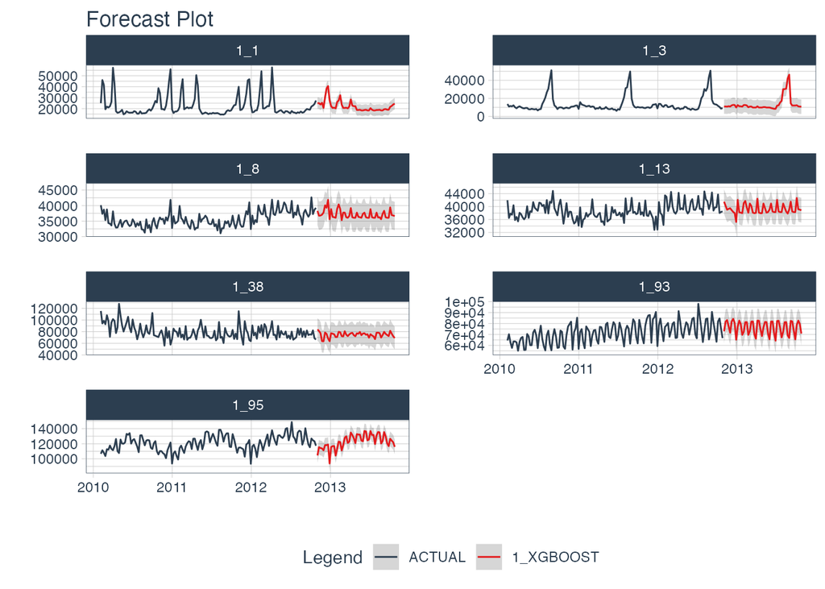

```r
refit_table %>%
  modeltime_forecast(
    new_data    = future_table,
    actual_data = data_table,
    conf_by_id  = TRUE
  ) %>%
  group_by(id) %>%
  plot_modeltime_forecast(
    .interactive = FALSE,
    .facet_ncol  = 2
  )
```

これでグローバルモデルを利用したモデリングの基礎的な部分は終わり。下記はおまけ。

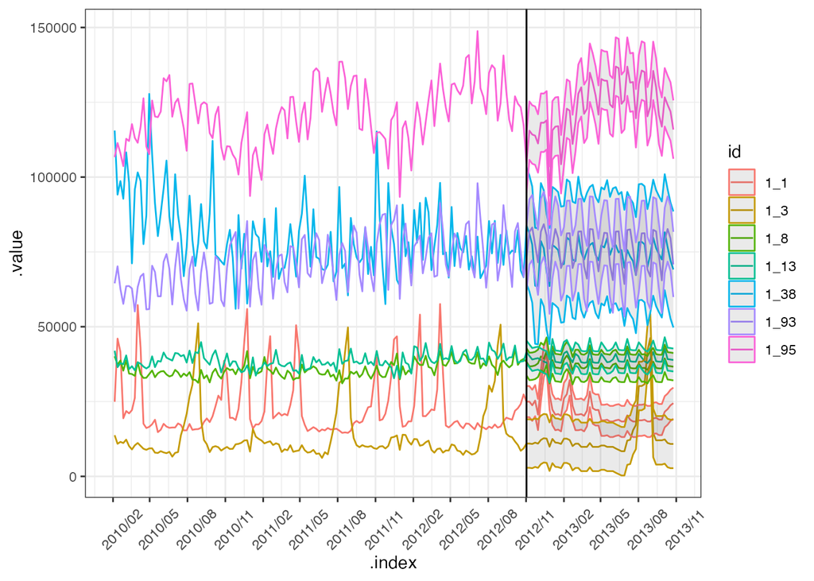

```r
refit_table %>%
  modeltime_forecast(
    new_data    = future_table,
    actual_data = data_table,
    conf_by_id  = TRUE
  ) %>%
  ggplot(aes(.index, .value, col = id)) +
  geom_line() +
  geom_ribbon(aes(ymin = .conf_lo, ymax = .conf_hi), alpha = 0.1) +
  geom_vline(xintercept = as.Date("2012-11-02")) +
  theme_bw() +
  scale_x_date(limits = c(as.Date("2010-02-01"), as.Date("2013-10-25    ")),
               labels = date_format("%Y/%m"),
               breaks = date_breaks("3 month")) +
  theme(axis.text.x = element_text(angle = 45, vjust = 0.2, hjust=0.2))
```

## 参考文献

- [Tidymodels](https://www.tidymodels.org/)
- [Tidy Modeling with R](https://www.tmwr.org/software-modeling.html)